# Krystal Biotech (KRYS) 기업 분석 보고서

Alpha Hunter Hidden Gem Week 21 — 유전자 치료 독점 플랫폼, VYJUVEK 폭풍 성장

Author

Alpha Hunter × Chimera AI

Published

May 21, 2026

# 기업 개요

| 항목 | 내용 |
| --- | --- |
| **종목명** | Krystal Biotech, Inc. (KRYS, NASDAQ) |
| **업종** | Healthcare / Biotechnology — 유전자 치료제 |
| **핵심 사업** | VYJUVEK (수포성 표피박리증 유전자 치료제) + 파이프라인 |
| **시총** | $8.9B (약 12.5조원) |
| **현재가** | $302.05 |
| **PER (TTM/Fwd)** | 40.5x / 30.0x |
| **PSR** | 21.3x |
| **배당수익률** | 0% |
| **컨센서스** | Strong Buy (Buy 9 / Hold 1 / Sell 0) |
| **목표가** | $241 ~ $399 (평균 $323) |

**핵심 투자 포인트**

**세계 최초 FDA 승인 유전자 치료제 VYJUVEK 독점.** Q1 2026 매출 $116.4M (+32% YoY), 영업이익률 46%, 현금 $1B, 부채 거의 Zero. 52주 저점 $122 → 현재 $302 (+146% 상승). SEPA 7/7 Stage 2 상승 추세 확인. **2026년 KB803(안과), KB801(낭포성섬유증) 2개 파이프라인 임상 데이터 발표 예정** — 파이프라인 성공 시 TAM 10배 확장.

## 0.1 사업 요약

Krystal Biotech는 **세계 최초이자 유일한 FDA 승인 유전자 치료제(VYJUVEK)** 을 보유한 상업화 단계 바이오텍이다.

- **VYJUVEK** — 수포성 표피박리증(DEB) 치료를 위한 유전자 치료제. 2023년 FDA 승인 후 폭발적 성장
- **Q1 2026 매출 $116.4M** — YoY +32%, QoQ +9% 가속 성장. 미국 $87.5M + 해외 $28.9M
- **95% 매출총이익률** — 바이오텍 중 최상위. 영업이익률 46%
- **현금 $1.0B, 부채 $10M** — 사실상 무부채. 파이프라인 투자 여력 충분
- **파이프라인 확장** — KB803(안과 DEB), KB801(낭포성섬유증), KB407, KB111 등 다수 진행
- **이탈리아·스페인 출시 예정** — H2 2026 유럽 확장으로 매출 가속 기대

## 0.2 투자 논리: AROC 성공패턴 적용

AROC 성공패턴(인프라독점 + 가동률 + 배당 + 성장)을 Krystal Biotech에 대입하면:

- **인프라 독점**: 세계 유일 FDA 승인 유전자 치료제. 경쟁사 부재. 특허 장벽 강력
- **가동률**: VYJUVEK 환자 수 지속 증가. 미국 시장 포화 전 유럽·일본 확장으로 자연 성장
- **주주환원**: 아직 배당 없으나, 현금 $1B+로 자사주매입 또는 향후 배당 가능성
- **성장**: 매출 +32% YoY 가속, EPS +52.5% 성장, 2개 파이프라인 데이터 2026년 예정

# 1 차트 분석

## 1.1 SEPA 트렌드 템플릿 (Stage 2 상승 추세)

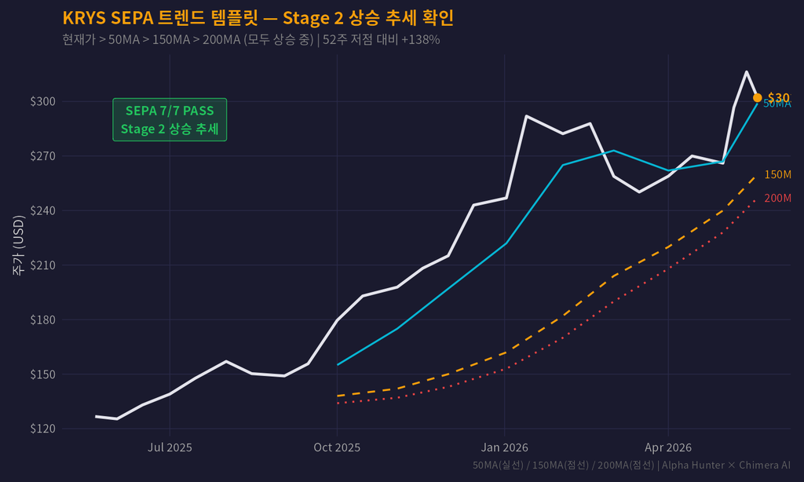

Figure 1: KRYS SEPA 트렌드 템플릿 — 모든 이평선 위에서 Stage 2 상승 추세 확인 ✅ 7/7 PASS

## 1.2 주가 추이 (52주) + 52주 고/저점 위치

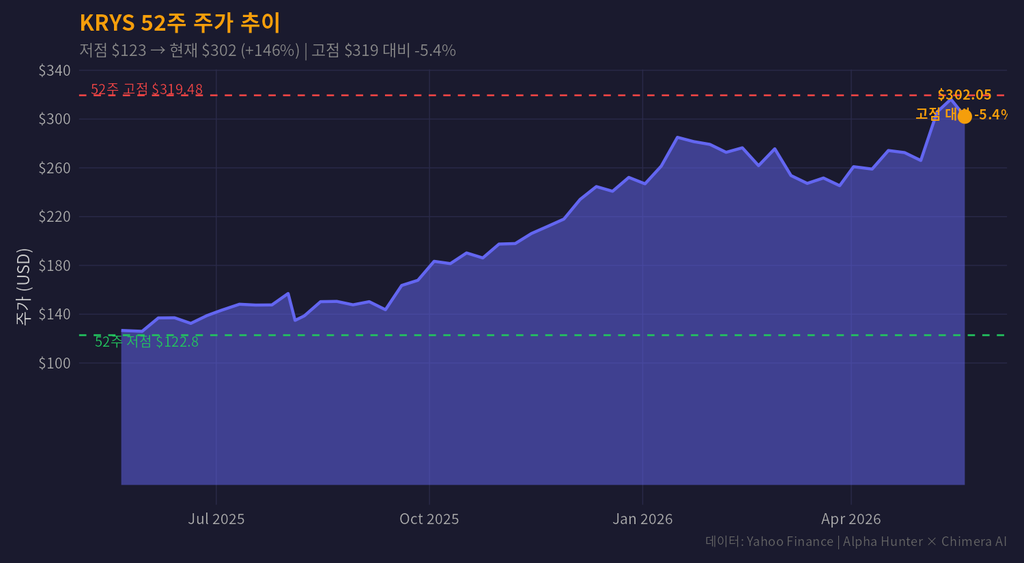

Figure 2: KRYS 52주 주가 추이 — 저점 $123에서 +146% 상승, 고점 $319 대비 -5.4%

## 1.3 실적 추이 (매출/영업이익 분기별)

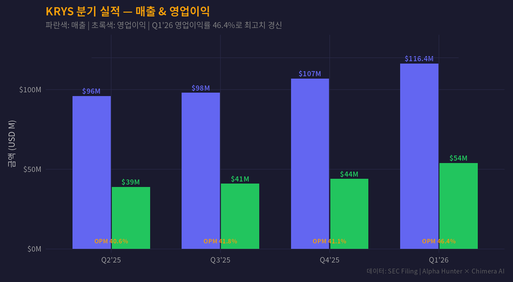

Figure 3: KRYS 분기 실적 — 매출 4분기 연속 가속, 영업이익률 40%+ 유지

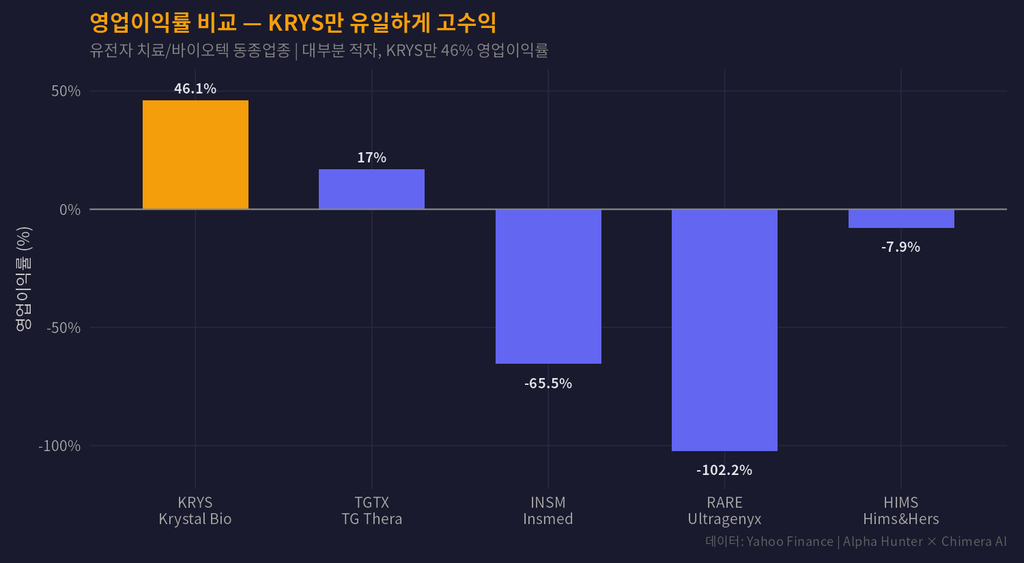

## 1.5 워런 버핏 해자 레이더 차트

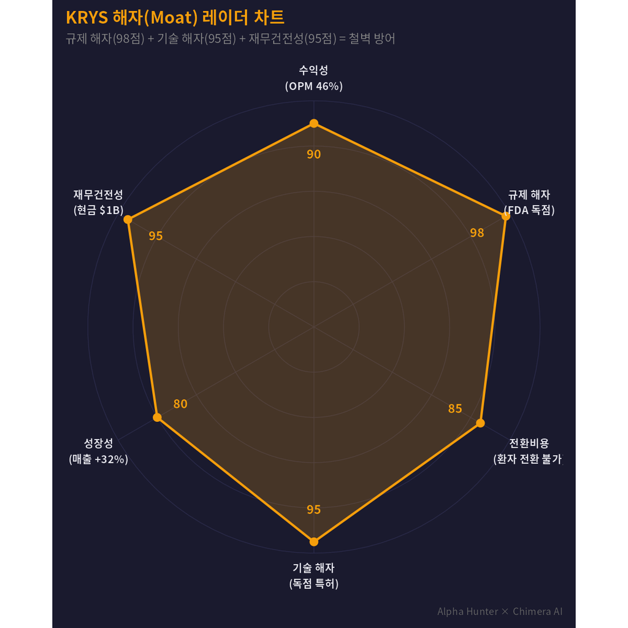

Figure 5: KRYS 해자(Moat) 분석 — FDA 독점 승인 + 특허 + 무부채 = 철벽 해자

## 1.6 피터 린치 스토리 점수

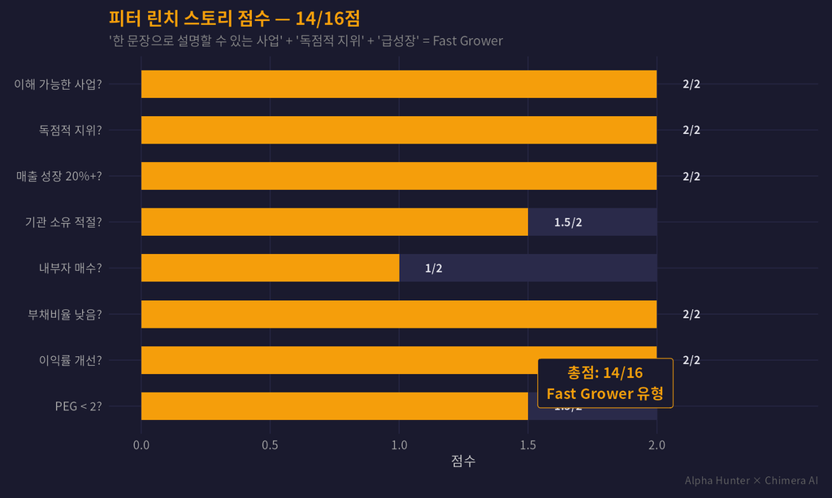

Figure 6: KRYS 피터 린치 스토리 분석 — 14/16점, ‘Fast Grower’ 유형

## 1.7 리스크 팩터 대시보드

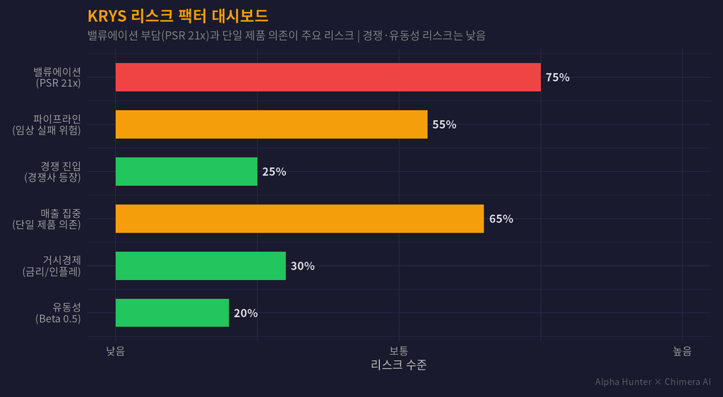

## 1.8 매수/목표/손절가 시나리오 (R:R 비율)

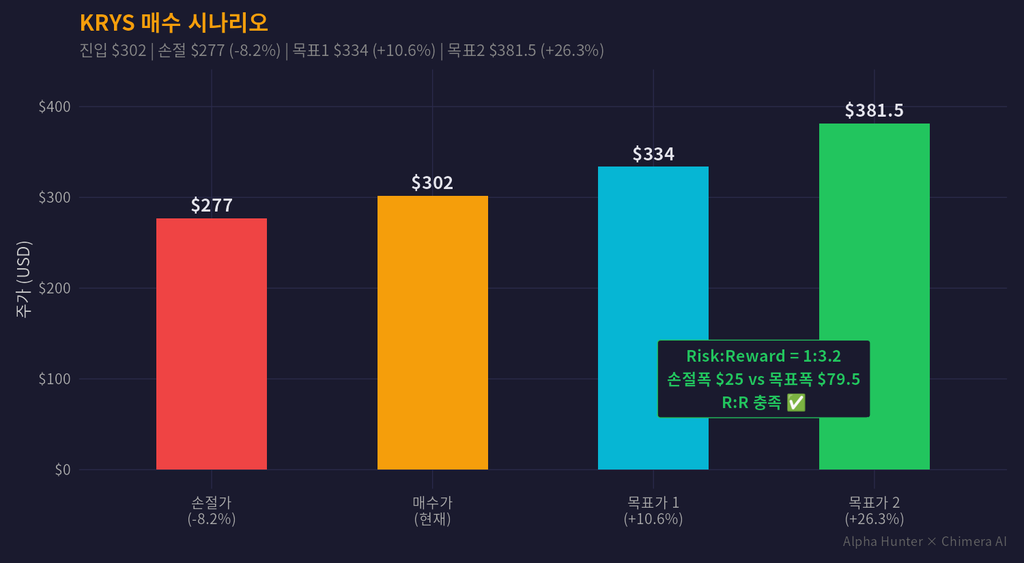

Figure 8: KRYS 매수 시나리오 — Risk:Reward = 1:3.2, 하방 -8.2% vs 상방 +26.3%

# 2 카탈리스트 & 타임라인

| 시기 | 카탈리스트 | 임팩트 |
| --- | --- | --- |
| **2026 H2** | 이탈리아·스페인 VYJUVEK 출시 | 유럽 매출 +50% 기대 |
| **2026 Q4** | KB803 (안과 DEB) IOLITE 임상 top-line 데이터 | 성공 시 TAM 5x 확장 |
| **2026 Q4** | KB801 (낭포성섬유증) 완전 등록 → 데이터 | 블록버스터 잠재력 |
| **2027** | KB407/KB111 FDA 플랫폼 기술 지정 활용 | 파이프라인 가속 |

# 3 리스크 요인

1. **밸류에이션 부담**: PSR 21x, Forward PE 30x. 성장 지속이 필수. 성장 둔화 시 멀티플 압축 리스크
2. **단일 제품 의존**: 매출 100%가 VYJUVEK. 파이프라인 실패 시 성장 스토리 훼손
3. **파이프라인 리스크**: KB803, KB801 임상 실패 가능성. 유전자 치료 특성상 안전성 이슈 돌발 가능
4. **시장 규모 한계**: DEB 환자 수가 제한적(미국 ~2.5만명). 현재 침투율이 높아질수록 성장 둔화

# 4 결론

**투자 판단**

**Krystal Biotech (KRYS)는 SEPA 7/7 Stage 2 상승 추세에 있는 유전자 치료 독점 플랫폼이다.**

- 세계 유일 FDA 승인 유전자 치료제 VYJUVEK 보유
- Q1 2026 매출 $116.4M (+32% YoY), 영업이익률 46%
- 현금 $1B, 부채 거의 Zero — 바이오텍 중 최강 재무
- 2026년 2개 파이프라인 데이터 발표 → TAM 대폭 확장 가능성
- Strong Buy 컨센서스 (9명), 목표가 평균 $323

**매수가 $302 | 목표가 $381.5 | 손절가 $277 | R:R = 1:3.2**

**면책 문구**

이 프로젝트는 가상 투자 시뮬레이션 목적으로 작성되었습니다. 실제 투자 권유가 아닙니다.